# Regression Project.Rmd

Harold Trammel

September 7, 2015

A data frame with 32 observations on 11 variables.

```
[, 1]   mpg     Miles/(US) gallon
[, 2]   cyl     Number of cylinders
[, 3]   disp    Displacement (cu.in.)
[, 4]   hp      Gross horsepower
[, 5]   drat    Rear axle ratio
[, 6]   wt      Weight (lb/1000)
[, 7]   qsec    1/4 mile time
[, 8]   vs      Vee vs Straight Cylinder Arrangement
[, 9]   am      Transmission (0 = automatic, 1 = manual)
[,10]   gear    Number of forward gears
[,11]   carb    Number of carburetors
```

```r
all_fit <- lm(mpg ~ . , data = mtcars)
all_fit_coef <- summary(all_fit)$coef
kable(all_fit_coef, caption="All Fit Coefficients")
```

All Fit Coefficients

|  | Estimate | Std. Error | t value | Pr(>\|t\|) |
| --- | --- | --- | --- | --- |
| (Intercept) | 12.3034 | 18.7179 | 0.6573 | 0.5181 |
| cyl | -0.1114 | 1.0450 | -0.1066 | 0.9161 |
| disp | 0.0133 | 0.0179 | 0.7468 | 0.4635 |
| hp | -0.0215 | 0.0218 | -0.9868 | 0.3350 |
| drat | 0.7871 | 1.6354 | 0.4813 | 0.6353 |
| wt | -3.7153 | 1.8944 | -1.9612 | 0.0633 |
| qsec | 0.8210 | 0.7308 | 1.1234 | 0.2739 |
| vs | 0.3178 | 2.1045 | 0.1510 | 0.8814 |
| am | 2.5202 | 2.0567 | 1.2254 | 0.2340 |
| gear | 0.6554 | 1.4933 | 0.4389 | 0.6652 |
| carb | -0.1994 | 0.8288 | -0.2406 | 0.8122 |

```r
am_fit <- lm(mpg ~ am, data = mtcars)
am_fit_coef <- summary(am_fit)$coef
kable(am_fit_coef, caption="All Fit Coefficients")
```

|  | Estimate | Std. Error | t value | Pr(>\|t\|) |
| --- | --- | --- | --- | --- |
| (Intercept) | 17.147 | 1.125 | 15.248 | 0.0000 |
| am | 7.245 | 1.764 | 4.106 | 0.0003 |

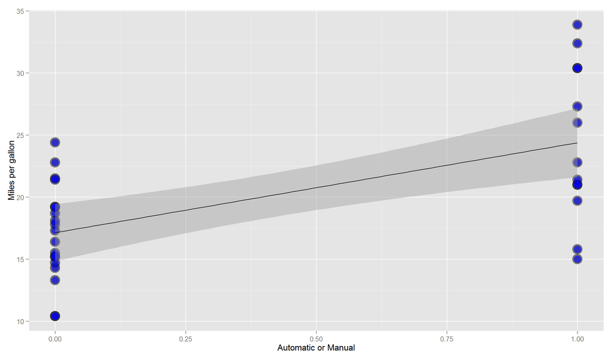

```r
g_am = ggplot(mtcars, aes(x = am, y = mpg)) +
    ylab("Miles per gallon") +
    xlab("Automatic or Manual") +
    geom_point(aes(y=mpg), size = 7, colour = "black", alpha=0.5) +
    geom_point(aes(x=am),size = 5, colour = "blue", alpha=0.6) +
    geom_smooth(method = "lm", colour = "black")
print(g_am)
```

```r
auto_df <- mtcars %>%
            filter(am == 0) %>%
            select(one_of(c("mpg")))
manual_df <- mtcars %>%
            filter(am == 1) %>%
            select(one_of(c("mpg")))

desc_stat_lbl <- c("number of values (nbr.val) "
                    ,"number of null values (nbr.null) "
                    ,"number of missing values (nbr.na)"
                    ,"minimal value (min)"
                    ,"maximal value (max)"
                    ,"range (range that is max-min)"
                    ,"sum of all non-missing values (sum)"
                    ,"median (median)"
                    ,"mean (mean)"
                    ,"standard error on mean (SE.mean) "
                    ,"confidence interval of mean (CI.mean)"
                    ,"variance (var) "
                    ,"standard deviation (std.dev) "
                    ,"variation coefficient (coef.var)")
stat_table <- data.frame(matrix(data=1:42, nrow=14, ncol=1))
stat_table[,1] <- desc_stat_lbl
stat_table <- cbind(stat_table, stat.desc(auto_df), stat.desc(manual_df))
names(stat_table) <- c("Statistic", "auto", "manual")

kable(stat_table, digits = getOption("digits"), row.names=F, col.names = c("Statistic", "Automatic", "Manual"))
```

| Statistic | Automatic | Manual |
| --- | --- | --- |
| number of values (nbr.val) | 19.0000 | 13.0000 |
| number of null values (nbr.null) | 0.0000 | 0.0000 |
| number of missing values (nbr.na) | 0.0000 | 0.0000 |
| minimal value (min) | 10.4000 | 15.0000 |
| maximal value (max) | 24.4000 | 33.9000 |
| range (range that is max-min) | 14.0000 | 18.9000 |
| sum of all non-missing values (sum) | 325.8000 | 317.1000 |
| median (median) | 17.3000 | 22.8000 |
| mean (mean) | 17.1474 | 24.3923 |
| standard error on mean (SE.mean) | 0.8796 | 1.7103 |
| confidence interval of mean (CI.mean) | 1.8479 | 3.7264 |
| variance (var) | 14.6993 | 38.0258 |
| standard deviation (std.dev) | 3.8340 | 6.1665 |
| variation coefficient (coef.var) | 0.2236 | 0.2528 |

## *Motor Trend* Car Road Tests

Evaluation Criteria

- Did the student interpret the coefficients correctly?
- Did the student do some exploratory data analyses?
- Did the student fit multiple models and detail their strategy for model selection?
- Did the student answer the questions of interest or detail why the question(s) is (are) not answerable?
- Did the student do a residual plot and some diagnostics?
- Did the student quantify the uncertainty in their conclusions and/or perform an inference correctly?
- Was the report brief (about 2 pages long) for the main body of the report and no longer than 5 with supporting appendix of figures?
- Did the report include an executive summary?
- Was the report done in Rmd (knitr)?

### Introduction

*Motor Trend* is interested in exploring the relationship between a set of variables and miles per gallon (MPG) (outcome). They have provided a set of data from automobiles that they tested over a period of time. They are particularly interested in the following two questions:

- “Is an automatic or manual transmission better for MPG”
- “Quantify the MPG difference between automatic and manual transmissions”

A modern automobile is a complex machine and as such no one component is fully responsible for its performance and efficiency. Some of the cars in the sample have been designed for performance while others were designed for performance or luxury. This inherent complexity must be kept in mind when looking a single complonent such as the type of transmission.

### General Exploration

The data that *Motor Trend* provided was eleven different measured collected from 32 different automobiles. Three of the variables (Miles Per Gallon, Gross Horsepower, and 1/4 Mile Time) are dependent on different sets of the other variables. Some of the variables are factors even though their values are numeric. These are: Number of Cylinders, Vee vs Straight Cylinder Arrangement, Transmission Type, Number of Forward Gears, and Number of Carburators. Displacement, Rear Axle Ratio, and Weight are continous variables.

I compared the statistics related to milage recorded in cars with automatic transmissions to those with manual. The mean milage in automatic cars was 17.1474 ± 0.8796.